# me20260916_Hop_Eff_Clones_Lise

Mathias

2026-09-16

# Aim

Determine the Excision and reintegration efficiency of Sleeping Beauty transposons containing the same insert from different genomic loci.

# Experimental setup

Clonal cell lines containing the SB cassette at different precise genomic locations were subject to SB mediated hopping by transfecting the cells with the SB transposase. Single cell clones were isolated from the hopped population and screened for evidence of hopping by PCR. Clones that showed indication of hopping were selected and subject to Tn5-based mapping.

Here is the selection and analysis of excised and reintegrated clones from Figure 1C.

# Experiments

E1682 - mapping of clones for Fzd5, Tdgf1, Nanog E1792 - mapping of clones for T3, T48, T201, F108, N31, N37 E1828 - mapping of clones for T3, T48, T201

##NOTE clone T201 has probably a second LP (30Mb) away, which causes weird distributions. Therefore filter it out.

#Setup

```r
library(stringr)
library(dplyr)
```

```r
library(readr)
library(tidyr)
library(ggplot2)
library(Biostrings)
library(scales)
split_string <- function(vect,sep,N1,N2=N1){
  library(stringr)
  sapply(vect, function(X){
    paste(str_split(X,sep)[[1]][N1:N2],collapse = sep)
  },USE.NAMES = F)
}
```

#Paths and parameters

```r
#datatag
datetag = paste0("CM",format(Sys.time(), '%Y%m%d'))

# Prepare output
output_dir <- paste0("/home/c.moene/projects/hopping_technology/08_Clones_transposition_eff/analysis_",datetag,"/")
dir.create(output_dir, showWarnings = FALSE)
```

```r
library(knitr)
opts_chunk$set(cache = F,
               message = F, warning = F,
               dev=c('png', 'pdf'),
               dpi = 300,
               fig.path = paste0(file.path(output_dir)))
pdf.options(useDingbats = FALSE)
```

#Annotate Landing pads

```r
N37 <- GenomicRanges::GRanges(seqnames = "chr6", ranges = IRanges(start = 109001001, end = 109001001), strand = "*")
N31 <- GenomicRanges::GRanges(seqnames = "chr6", ranges = IRanges(start = 143694590, end = 143694590), strand = "*")
F108 <- GenomicRanges::GRanges(seqnames = "chr1", ranges = IRanges(start = 79293542, end = 79293542), strand = "*")
T201 <- GenomicRanges::GRanges(seqnames = "chr9", ranges = IRanges(start = 112440264, end = 112440264), strand = "*")
T137 <- GenomicRanges::GRanges(seqnames = "chr9", ranges = IRanges(start = 110925104, end = 110925104), strand = "*")
T48 <- GenomicRanges::GRanges(seqnames = "chr9", ranges = IRanges(start = 109626922, end = 109626922), strand = "*")
T3 <- GenomicRanges::GRanges(seqnames = "chr9", ranges = IRanges(start = 109077722, end = 109077722), strand = "*")
Tdgf1 <- GenomicRanges::GRanges(seqnames = "chr9", ranges = IRanges(start = 110927601, end = 110927601), strand = "*")
Fzd5 <- GenomicRanges::GRanges(seqnames = "chr1", ranges = IRanges(start = 64993483, end = 64993483), strand = "*")
```

#Load clonal integration data from processed file

```r
clones_int_fig1 = read_tsv("/home/c.moene/projects/hopping_technology/GEO_upload/processed_datafiles/mapping_SB_ints_clones.txt")
```

# E1682

```r
clones_E1682 = clones_int_fig1 %>% filter(experiment == "E1682")

#Determine read cutoff for clones
clone_summary <- clones_E1682 %>%
  group_by(sample) %>%
  mutate(
    total_reads_sample = sum(read_count, na.rm = TRUE),
    fract_reads_sample = read_count / total_reads_sample
  ) %>%
  arrange(sample, desc(read_count)) %>%
  mutate(rank_in_sample = row_number()) %>%
  ungroup()
```

```r
# choose thresholds
min_reads <- 3
min_fraction <- 0.2

reliable_integrations <- clone_summary %>%
  filter(read_count >= min_reads, fract_reads_sample >= min_fraction)

# number of clones with >=1 reliable integration
n_clones_with_reliable <- reliable_integrations %>%
  summarise(n_clones = n_distinct(sample))

# per Launch site
clones_per_LS <- reliable_integrations %>%
  distinct(sample, launch_site) %>%
  dplyr::count(launch_site, name = "n_clones_with_reliable_integration")

# how many reliable integrations per clone
integrations_per_clone <- reliable_integrations %>%
  dplyr::count(sample, name = "n_reliable_integrations")

clone_class_summary <- integrations_per_clone %>%
  dplyr::count(n_reliable_integrations, name = "n_clones")

# outputs
n_clones_with_reliable
```

```
## # A tibble: 1 × 1
##   n_clones
##      <int>
## 1      111
```

```r
clones_per_LS
```

```
## # A tibble: 3 × 2
##   launch_site n_clones_with_reliable_integration
##   <chr>                                    <int>
## 1 Fzd5                                        30
## 2 Nanog                                       33
## 3 Tdgf1                                       48
```

```r
integrations_per_clone
```

```
## # A tibble: 111 × 2
##    sample         n_reliable_integrations
##    <chr>                            <int>
##  1 Fzd5_clone_100                       1
##  2 Fzd5_clone_108                       1
##  3 Fzd5_clone_11                        1
##  4 Fzd5_clone_12                        1
##  5 Fzd5_clone_123                       1
##  6 Fzd5_clone_125                       1
##  7 Fzd5_clone_13                        1
##  8 Fzd5_clone_132                       1
##  9 Fzd5_clone_137                       1
## 10 Fzd5_clone_146                       1
## # ℹ 101 more rows
```

```r
clone_class_summary
```

```
## # A tibble: 2 × 2
##   n_reliable_integrations n_clones
##                     <int>    <int>
## 1                       1       97
## 2                       2       14
```

**Conclusion:** I filtered each clone to have at least 3 reads per putative integration side and that the integration should represent at least 20% of the total reads. By applying this filters, we find 30 int –> Fzd5 33 int –> Nanog 48 int –> Tdgf1

## Quality control - chromosomal distribution

```r
# On which chromosomes are the integrations
reliable_integrations %>%
  group_by(launch_site, chr) %>%
  summarise(n = n())
```

```
## # A tibble: 20 × 3
## # Groups:   launch_site [3]
##    launch_site chr       n
##    <chr>       <chr> <int>
##  1 Fzd5        chr1     28
##  2 Fzd5        chr16     1
##  3 Fzd5        chr3      1
##  4 Fzd5        chr6      1
##  5 Fzd5        chr8      1
##  6 Fzd5        chr9      1
##  7 Nanog       chr10     1
##  8 Nanog       chr13     1
##  9 Nanog       chr15     1
## 10 Nanog       chr17     1
## 11 Nanog       chr6     31
## 12 Nanog       chr9      1
## 13 Nanog       chrX      1
## 14 Tdgf1       chr1     19
## 15 Tdgf1       chr10     1
## 16 Tdgf1       chr13     1
## 17 Tdgf1       chr2      1
## 18 Tdgf1       chr3      1
## 19 Tdgf1       chr5      1
## 20 Tdgf1       chr9     31
```

```r
#There is an issue that 19 integrations are found on chr1, when looking at them it looks like they are coming from Fzd5_108 ()
reliable_integrations %>% filter(launch_site == "Tdgf1") %>% group_by(sample, chr) %>% summarise(n = n())
```

```
## # A tibble: 53 × 3
## # Groups:   sample [48]
##    sample          chr       n
##    <chr>           <chr> <int>
##  1 Tdgf1_clone_1   chr9      2
##  2 Tdgf1_clone_109 chr9      1
##  3 Tdgf1_clone_111 chr1      1
##  4 Tdgf1_clone_114 chr1      1
##  5 Tdgf1_clone_114 chr9      1
##  6 Tdgf1_clone_115 chr9      1
##  7 Tdgf1_clone_116 chr1      1
##  8 Tdgf1_clone_121 chr1      1
##  9 Tdgf1_clone_122 chr9      1
## 10 Tdgf1_clone_131 chr1      1
## # ℹ 43 more rows
```

```r
reliable_integrations %>% filter(launch_site == "Tdgf1") %>% distinct(sample) %>% summarise(count = n())
```

```
## # A tibble: 1 × 1
##   count
##   <int>
## 1    48
```

```r
reliable_integrations %>% filter(launch_site == "Tdgf1" & start != "79293540") %>% distinct(sample) %>% summarise(count = n())
```

```
## # A tibble: 1 × 1
##   count
##   <int>
## 1    34
```

## Check Tdgf1 contamination

```r
# Check if integtations that have the contamination also have another integration
reliable_integrations %>% filter(launch_site == "Tdgf1") %>% group_by(sample, chr) %>% summarise(count = n())
```

```
## # A tibble: 53 × 3
## # Groups:   sample [48]
##    sample          chr   count
##    <chr>           <chr> <int>
##  1 Tdgf1_clone_1   chr9      2
##  2 Tdgf1_clone_109 chr9      1
##  3 Tdgf1_clone_111 chr1      1
##  4 Tdgf1_clone_114 chr1      1
##  5 Tdgf1_clone_114 chr9      1
##  6 Tdgf1_clone_115 chr9      1
##  7 Tdgf1_clone_116 chr1      1
##  8 Tdgf1_clone_121 chr1      1
##  9 Tdgf1_clone_122 chr9      1
## 10 Tdgf1_clone_131 chr1      1
## # ℹ 43 more rows
```

```r
#which samples have integratios in different chr?
reliable_integrations %>% filter(launch_site == "Tdgf1") %>% group_by(sample, chr) %>% summarise(count = n()) %>% group_by(sample) %>% summarise(nr = n()) %>% arrange(desc(nr))
```

```
## # A tibble: 48 × 2
##    sample             nr
##    <chr>           <int>
##  1 Tdgf1_clone_114     2
##  2 Tdgf1_clone_135     2
##  3 Tdgf1_clone_177     2
##  4 Tdgf1_clone_201     2
##  5 Tdgf1_clone_33      2
##  6 Tdgf1_clone_1       1
##  7 Tdgf1_clone_109     1
##  8 Tdgf1_clone_111     1
##  9 Tdgf1_clone_115     1
## 10 Tdgf1_clone_116     1
## # ℹ 38 more rows
```

```r
Tdgf1_cont_samples_with_second_int = reliable_integrations %>%
  filter(launch_site == "Tdgf1") %>%
  group_by(sample, chr) %>%
  summarise(count = n()) %>%
  group_by(sample) %>%
  summarise(nr = n()) %>%
  filter(nr >1) %>%
  dplyr::pull(sample)


#Investigate suspicious samples
#reliable_integrations %>% filter(sample %in% Tdgf1_cont_samples_with_second_int) %>% View()

# New reliable integration tibble
# - filter out Tdgf1 clones that have contamination

clone_Tdgf1_cont = reliable_integrations %>% filter(launch_site == "Tdgf1" & chr == "chr1" & start == "79293540") %>% pull(sample)
clone_Tdgf1_cont_exclude =  setdiff(clone_Tdgf1_cont, Tdgf1_cont_samples_with_second_int)

#Filter out Tdgf1 clones that are contaminations
reliable_integrations_1 = reliable_integrations %>%
  filter(!sample %in% clone_Tdgf1_cont_exclude)

clones_per_LP_1 =
  reliable_integrations_1 %>%
  distinct(sample, launch_site) %>%
  dplyr::count(launch_site, name = "n_clones_with_reliable_integration")

clones_per_LP_1
```

```
## # A tibble: 3 × 2
##   launch_site n_clones_with_reliable_integration
##   <chr>                                    <int>
## 1 Fzd5                                        30
## 2 Nanog                                       33
## 3 Tdgf1                                       34
```

**Conclusion:** Clones “Tdgf1_clone_114” “Tdgf1_clone_135” “Tdgf1_clone_177” “Tdgf1_clone_201” “Tdgf1_clone_33” have a contaminating integration from the Fzd5_F108 LP in them but also a second integration that is reasonable. Therefore i believe them to be real.

Fzd5 - 30 Nanog - 33 Tdgf1 - 34

# E1792

```r
clones_E1792 = clones_int_fig1 %>% filter(experiment == "E1792")
```

## Quality control

```r
# How many clones do we have per launch pad
clones_E1792 %>%
  group_by(launch_site) %>%
  distinct(sample) %>%
  dplyr::count()
```

```
## # A tibble: 2 × 2
## # Groups:   launch_site [2]
##   launch_site     n
##   <chr>       <int>
## 1 T3              2
## 2 T48             5
```

```r
# How many do have reliable integrations?
clone_summary_E1792 <- clones_E1792 %>%
  group_by(sample) %>%
  mutate(
    total_reads_sample = sum(read_count, na.rm = TRUE),
    fract_reads_sample = read_count / total_reads_sample
  ) %>%
  arrange(sample, desc(read_count)) %>%
  mutate(rank_in_sample = row_number()) %>%
  ungroup()

# Select the top two ranked ones
clone_summary_E1792 %>%
  filter(rank_in_sample <= 2) %>%
  group_by(sample, launch_site) %>%
  dplyr::count(sample)
```

```
## # A tibble: 7 × 3
## # Groups:   sample, launch_site [7]
##   sample   launch_site     n
##   <chr>    <chr>       <int>
## 1 T3_cl3   T3              2
## 2 T3_cl6   T3              2
## 3 T48_cl10 T48             2
## 4 T48_cl2  T48             1
## 5 T48_cl3  T48             2
## 6 T48_cl6  T48             2
## 7 T48_cl7  T48             2
```

```r
clone_summary_E1792 %>%
  filter(rank_in_sample <= 2) %>%
  distinct(sample, launch_site) %>%
  dplyr::count(launch_site, name = "n_samples")
```

```
## # A tibble: 2 × 2
##   launch_site n_samples
##   <chr>           <int>
## 1 T3                  2
## 2 T48                 5
```

```r
#Cutoff - each integration requires at least 10 reads
clone_summary_E1792 %>%
  filter(read_count >= 10) %>%
  group_by(launch_site) %>%
  summarize(count = n())
```

```
## # A tibble: 1 × 2
##   launch_site count
##   <chr>       <int>
## 1 T48             2
```

```r
# Filter
clone_summary_E1792_filtered =
clone_summary_E1792  %>%
  filter(read_count >= 10)
```

**Conclusion:** In this samples there is a lot of background noise in there, I figured filtering for 10 reads per integration should give a robust cutoff. T48 –> 2 clones T3 –> none left (all ints had very low read counts)

#E1828

```r
clones_E1828 = clones_int_fig1 %>% filter(experiment == "E1828")
```

##Quality controls

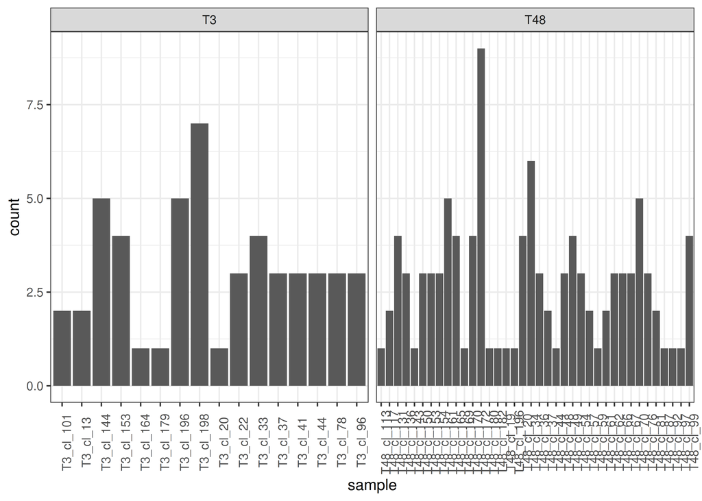

```r
# Annotate mapped SB arms
clones_E1828 = clones_E1828 %>%
  mutate(mapped_arms = case_when(read_count_1 == 0 ~ "rv_only",
                                 read_count_2 == 0 ~ "fw_only",
                                 read_count_1 > 0 & read_count_2 > 0 ~ "both_arms"))


# Number of insertions per clone
clones_E1828 %>% group_by(launch_site, sample) %>% summarize(count = n()) %>%
  ggplot(aes(x = sample, y = count)) +
  geom_bar(stat = "identity") +
  facet_wrap(~ launch_site, scales = "free_x") +
  theme_bw() +
   theme(axis.text.x = element_text(angle = 90))
```

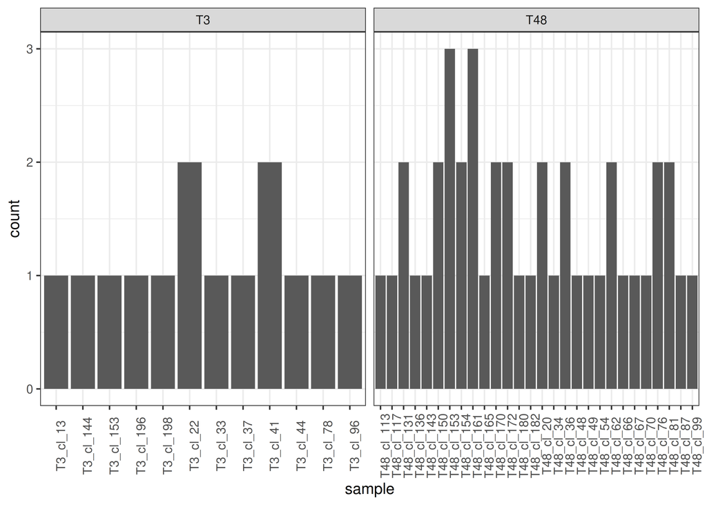

```r
clones_E1828 %>% filter(read_count >= 10) %>% group_by(launch_site, sample) %>% summarize(count = n()) %>%
  ggplot(aes(x = sample, y = count)) +
  geom_bar(stat = "identity") +
  facet_wrap(~ launch_site, scales = "free_x") +
  theme_bw() +
   theme(axis.text.x = element_text(angle = 90))
```

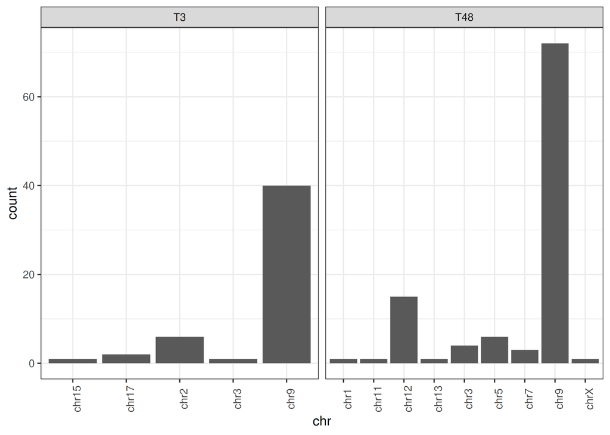

```r
#Which chromosomes are they
clones_E1828 %>% group_by(launch_site, sample, chr) %>% summarize(count = n()) %>%
  ggplot(aes(x = chr, y = count)) +
  geom_bar(stat = "identity") +
  facet_wrap(~ launch_site, scales = "free_x") +
  theme_bw() +
  theme(axis.text.x = element_text(angle = 90))
```

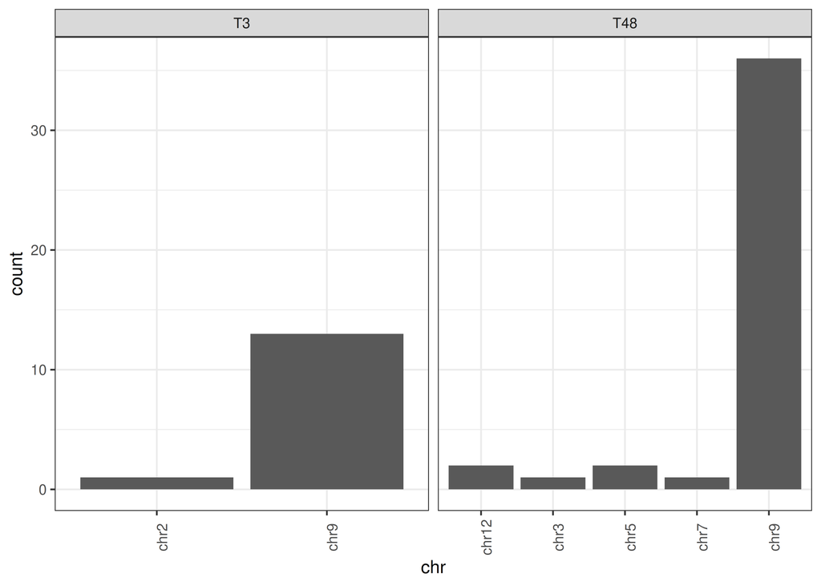

```r
#Filter for >=10 reads
clones_E1828 %>%
  filter(read_count >= 10) %>%
  group_by(launch_site, sample, chr) %>%
  summarize(count = n()) %>%
  ggplot(aes(x = chr, y = count)) +
  geom_bar(stat = "identity") +
  facet_wrap(~ launch_site, scales = "free_x") +
  theme_bw() +
  theme(axis.text.x = element_text(angle = 90))
```

```r
clones_E1828 %>%
  filter(read_count >= 10) %>%
  group_by(launch_site) %>%
  distinct(sample) %>%
  summarise(n = n())
```

```
## # A tibble: 2 × 2
##   launch_site     n
##   <chr>       <int>
## 1 T3             12
## 2 T48            28
```

```r
#Filtered tib
clones_E1828_filtered =
clones_E1828 %>%
  filter(read_count >= 10)
```

**Conclusion:** Filtering for >=10 reads per integration displays strong enrichment for the target chromosomes. Number of clones with 1 or more ints when filtered: T48 = 28 T3 = 12

# Plot clones

I collected the numbers of total clones, excised_&_reintegrated and excised_with_no_detectable_reintegration in excel and exported them as a tsv file to plot them here.

```r
tib_eff_clones_combined = read_tsv("/DATA/usr/m.eder/projects/Method_paper/Lise_hop_ReIntegrate_clone_estimation/me20260409_Clones_Lise_LD20260224.tsv")

#Filter out clone T201, has two integrations
tib_eff_clones_combined = tib_eff_clones_combined %>%
  filter(locus != "T201")
```

## Add count clone count to each categroy

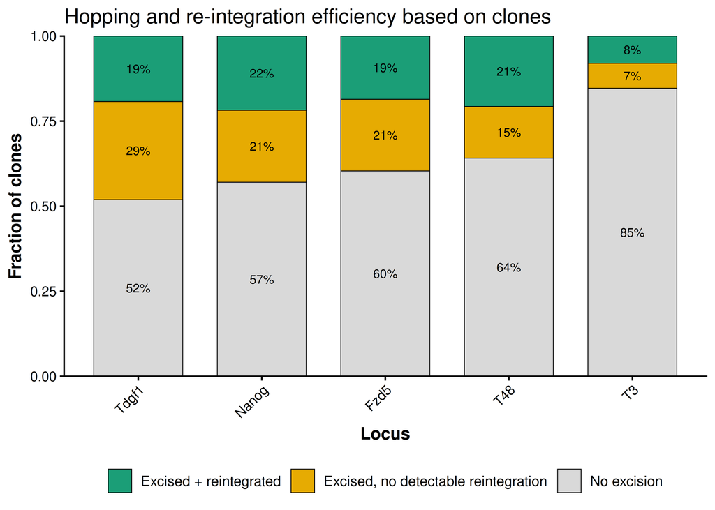

```r
plot_df <- tib_eff_clones_combined %>%
  mutate(hop_frac = hopped_out_clones / total_clones,
         reintegration_frac = clones_with_int / tagmented_clones,
         combined_frac = hop_frac * reintegration_frac,

         fract_no_excision_fraction = 1 - hop_frac,
         fract_exc_not_int_fraction = hop_frac * (1 - reintegration_frac),
         fract_exc_int_fraction = combined_frac,

         fract_no_excision_count = total_clones - hopped_out_clones,
         fract_exc_int_count = clones_with_int,
         fract_exc_not_int_count = tagmented_clones - clones_with_int) %>%
  select(locus,
         fract_no_excision_fraction, fract_exc_not_int_fraction, fract_exc_int_fraction,
         fract_no_excision_count, fract_exc_not_int_count, fract_exc_int_count) %>%

  pivot_longer(cols = -locus,
    # We split column names into TWO parts:
    # 1) category  → fract_exc_int / fract_exc_not_int / fract_no_excision
    # 2) .value    → tells pivot_longer which output column to fill
    #                ("fraction" or "count")
    names_to = c("category", ".value"),

    # Regex that splits column names like:
    # "fract_exc_int_fraction" → ("fract_exc_int", "fraction")
    # "fract_exc_int_count"    → ("fract_exc_int", "count")
    #
    # Explanation of pattern:
    # ^(.*)_(fraction|count)$
    #  ^        start of string
    #  (.*)     capture EVERYTHING before last "_"
    #           → this becomes "category"
    #  _        literal underscore
    #  (fraction|count)
    #           match either "fraction" or "count"
    #           → this becomes ".value"
    #  $        end of string
    names_pattern = "^(.*)_(fraction|count)$") %>%
  mutate(category = factor(category, levels = c("fract_exc_int", "fract_exc_not_int", "fract_no_excision"),
                           labels = c("Excised + reintegrated",
                                      "Excised, no detectable reintegration",
                                      "No excision")))



#order based on Hopped + reintegrated number
locus_order <- plot_df %>%
  filter(category == "No excision") %>%
  arrange(fraction) %>%
  pull(locus)


# Plot
plot_df %>%
mutate(locus = factor(locus, levels = locus_order)) %>% #order based on locus
ggplot(aes(x = locus, y = fraction, fill = category)) +
  geom_col(width = 0.72, color = "black", linewidth = 0.25) +
  geom_text(
    aes(label = scales::percent(fraction, accuracy = 1)),
    position = position_stack(vjust = 0.5),
    size = 3
  ) +
  scale_fill_manual(
    values = c(
      "Excised + reintegrated" = "#1B9E77",
      "Excised, no detectable reintegration" = "#E6AB02",
      "No excision" = "#D9D9D9")) +
  labs(
    x = "Locus",
    y = "Fraction of clones",
    fill = NULL
  ) +
  scale_y_continuous(expand = c(0,0)) +
  theme_classic(base_size = 12) +
  theme(
    axis.text.x = element_text(angle = 45, hjust = 1, vjust = 1),
    axis.title = element_text(face = "bold"),
    legend.position = "bottom",
    legend.text = element_text(size = 10),
    panel.border = element_blank()) +
  ggtitle("Hopping and re-integration efficiency based on clones")
```

## Plot including number of clones

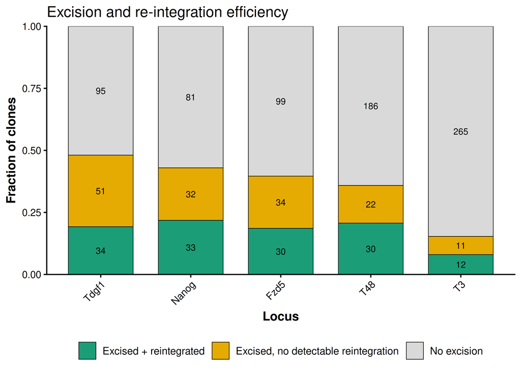

```r
# Plot with clone numbers in it
plot_df %>%
mutate(locus = factor(locus, levels = locus_order),
       category = factor(category, levels = c("Excised + reintegrated",
                                              "Excised, no detectable reintegration",
                                              "No excision"))) %>% #order based on locus
ggplot(aes(x = locus, y = fraction, fill = category)) +
  geom_col(width = 0.72, color = "black", linewidth = 0.25, position = position_stack(reverse = TRUE)) +
  geom_text(
    aes(label = (count)),
    position = position_stack(vjust = 0.5, reverse = TRUE),
    size = 3
    ) +
  scale_fill_manual(
    values = c(
      "Excised + reintegrated" = "#1B9E77",
      "Excised, no detectable reintegration" = "#E6AB02",
      "No excision" = "#D9D9D9")) +
  labs(
    x = "Locus",
    y = "Fraction of clones",
    fill = NULL
  ) +
  scale_y_continuous(expand = c(0,0)) +
  theme_classic(base_size = 12) +
  theme(
    axis.text.x = element_text(angle = 45, hjust = 1, vjust = 1),
    axis.title = element_text(face = "bold"),
    legend.position = "bottom",
    legend.text = element_text(size = 10),
    panel.border = element_blank()) +
  ggtitle("Excision and re-integration efficiency")
```

Calculate equivalent to ‘transposed fraction’ (for comparison to the pool-based estimates). Transposed fraction is excised_reintegrated/(excised_reintegrated + no_excision) Do this calculation based on the fractions, because those represent the whole experiment (counts are a bit off because not all excised clones were actually tagmented).

```r
plot_df %>%
  dplyr::select(-count) %>%
  pivot_wider(names_from = category,
              values_from = fraction) %>%
  mutate(transposed_fraction = `Excised + reintegrated`/(`Excised + reintegrated`+`No excision`)) %>%
  relocate(locus, transposed_fraction)
```

```
## # A tibble: 5 × 5
##   locus transposed_fraction `No excision` `Excised, no detectable reintegration`
##   <chr>               <dbl>         <dbl>                                  <dbl>
## 1 Fzd5               0.235          0.604                                 0.211
## 2 Tdgf1              0.270          0.519                                 0.289
## 3 Nanog              0.277          0.570                                 0.211
## 4 T48                0.244          0.641                                 0.152
## 5 T3                 0.0863         0.847                                 0.0733
## # ℹ 1 more variable: `Excised + reintegrated` <dbl>
```

# Extract the clonal names of the chosen ones

```r
reliable_integrations_sel = reliable_integrations_1 %>%
  dplyr::select(chr, start, end, strand, sample, read_count, launch_site)

clone_summary_E1792_filtered_sel = clone_summary_E1792_filtered %>% dplyr::select(chr, start, end, strand, sample, read_count, launch_site)

tib_E1828_filtered_sel = clones_E1828_filtered %>% dplyr::select(chr, start, end, strand, sample, read_count, launch_site)

tib_comb_selected_clones = rbind(reliable_integrations_sel, clone_summary_E1792_filtered_sel, tib_E1828_filtered_sel)

# How many clones with integrations do we have
tib_comb_selected_clones %>% group_by(launch_site) %>% distinct(sample) %>% summarise(n = n())
```

```
## # A tibble: 5 × 2
##   launch_site     n
##   <chr>       <int>
## 1 Fzd5           30
## 2 Nanog          33
## 3 T3             12
## 4 T48            30
## 5 Tdgf1          34
```

```r
# Distribution of integrations on chromosomes
tib_comb_selected_clones %>% group_by(launch_site, chr) %>% summarise(n = n())
```

```
## # A tibble: 27 × 3
## # Groups:   launch_site [5]
##    launch_site chr       n
##    <chr>       <chr> <int>
##  1 Fzd5        chr1     28
##  2 Fzd5        chr16     1
##  3 Fzd5        chr3      1
##  4 Fzd5        chr6      1
##  5 Fzd5        chr8      1
##  6 Fzd5        chr9      1
##  7 Nanog       chr10     1
##  8 Nanog       chr13     1
##  9 Nanog       chr15     1
## 10 Nanog       chr17     1
## # ℹ 17 more rows
```